# Titanic Tree

The dataset /home/bigdata/7/titanic.csv contains information on the passengers of the titanic. The following facts are recorded for each passenger: Class, Gender, Age. Class indication which category of ticket they had bought. The last fact the dataset contains is whether or not the passenger survived. Approach the task as follows:

```r
library(Hmisc)
X <- read.csv('titanic.csv',colClasses=c("NULL",NA,NA,NA,"NULL"))
Y <- read.csv('titanic.csv',colClasses=c("NULL","NULL","NULL","NULL",NA))
## 75% of the sample size
smp_size <- floor(0.75 * nrow(X))
## set the seed to make your partition reproductible
set.seed(123)
train_ind <- sample(seq_len(nrow(X)), size = smp_size)
Xtrain <- X[train_ind, ]
Xtest <- X[-train_ind, ]
Ytrain <- Y[train_ind, ]
Ytest <- Y[-train_ind, ]
summary(Xtrain)
```

```
  Class         Sex          Age
 1st :248   Female: 355   Adult:1574
 2nd :214   Male  :1295   Child:  76
 3rd :533
 Crew:655
```

Create a decision tree for all passengers and try to deduct useful rules for determining the survival or demise of a passenger.

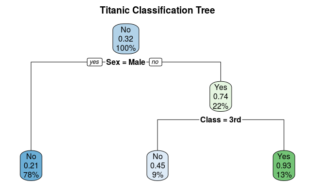

```r
#Classification (with two classes method=“poisson” else “class”)
library(rpart)
#plot tree
# install.packages('rpart.plot')
library(rpart.plot)
# has to be a dataframe to work with this package
Xtrain_df = as.data.frame(Xtrain)
# has to be a dataframe to work with this package
Xtest_df = as.data.frame(Xtest)
# Create a classification tree based on all inputs
tree = rpart(formula = Ytrain~., Xtrain_df, method="class")
rpart.plot(tree, main="Titanic Classification Tree")
```

```r
#predictions
p = predict(tree, Xtest_df, type="class")
#calculate misclassification rate
1-sum(diag(table(Ytest,p)))/sum(table(Ytest,p))
```

```
[1] 0.23049
```

```r
# summarize accuracy
table(Ytest, p)
```

```
     p
Ytest  No Yes
  No  368   6
  Yes 121  56
```

The previous analysis could give the impression that during the chaos of a sinking ship people were well behaved and let himself die in favour of other. One factor that the classification tree doesn’t take into consideration is the ratio of being a 3rd class. Below is a rerun of this same analysis but per Gender.

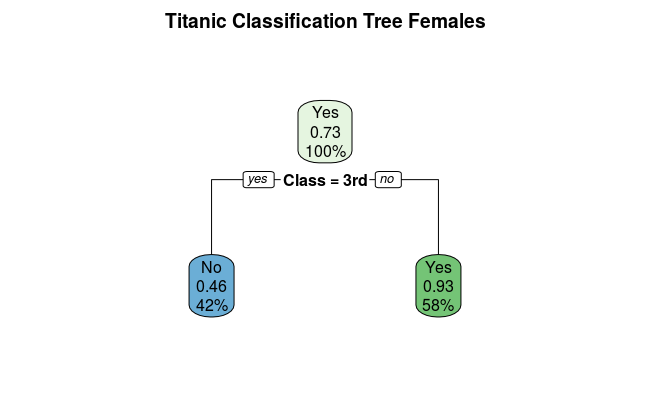

```r
XFemales <- as.data.frame(read.csv('titanic.csv',colClasses=c("NULL",NA,NA,NA,"NULL")))
YFemales <- as.data.frame(read.csv('titanic.csv',colClasses=c("NULL","NULL",NA,"NULL",NA)))
XFemales <- XFemales[ which(XFemales$Sex == "Female"),]
YFemales <- YFemales[ which(YFemales$Sex == "Female"),]
drops <- c("Sex")
YFemales <- YFemales[ , !(names(YFemales) %in% drops)]
#YFemales <- subset(YFemales, select=-c(Sex))
tree = rpart(formula = YFemales~., XFemales, method="class")
rpart.plot(tree, main="Titanic Classification Tree Females")
```

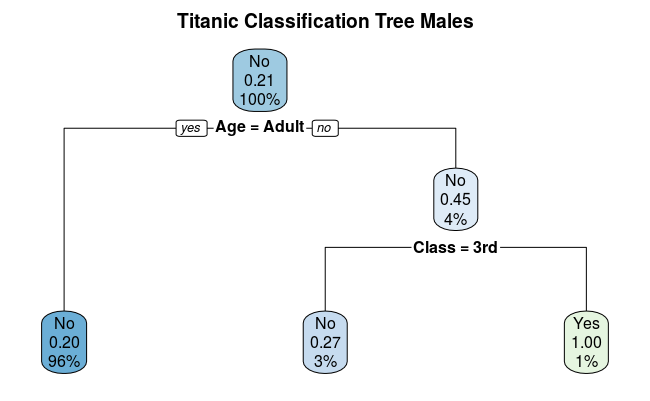

```r
XMales <- as.data.frame(read.csv('titanic.csv',colClasses=c("NULL",NA,NA,NA,"NULL")))
YMales <- as.data.frame(read.csv('titanic.csv',colClasses=c("NULL","NULL",NA,"NULL",NA)))
XMales <- XMales[ which(XMales$Sex == "Male"),]
YMales <- YMales[ which(YMales$Sex == "Male"),]
drops <- c("Sex")
YMales <- YMales[ , !(names(YMales) %in% drops)]
#YMales <- subset(YMales, select=-c(Sex))
tree = rpart(formula = YMales~., XMales, method="class")
rpart.plot(tree, main="Titanic Classification Tree Males")
```

• Execute k-fold-cross-validation to evaluate the accuracy of your decision tree1 • Compute the error rate of the predictions for k = (2, .., 10) and visualize false negative and false positive rates in a diagram. • Evaluate the quality of your predictions. How much training data is needed to yield some acceptable results?

```r
AllData <- as.data.frame(read.csv('titanic.csv',colClasses=c("NULL",NA,NA,NA,NA)))
meanError = 0
for(n_folds in 2:10){
errorList = 0
folds_i <- sample(rep(1:n_folds, length.out = dim(X)))
for (k in 1:n_folds) {
    test_i <- which(folds_i == k)
    train_xy <- AllData[-test_i, ]
    test_xy <- AllData[test_i, ]
    Ytrain = train_xy$Survived
    drops <- c("Survived")
    XTrain <- train_xy[ , !(names(train_xy) %in% drops)]

    Ytest = test_xy$Survived
    drops <- c("Survived")
    Xtest <- test_xy[ , !(names(test_xy) %in% drops)]

    # Create a classification tree based on all inputs
    tree = rpart(formula = Ytrain~., XTrain, method="class")
    #predictions
    p = predict(tree, Xtest, type="class")
    #calculate misclassification rate
    errorList <- append(errorList, 1-sum(diag(table(Ytest,p)))/sum(table(Ytest,p)))
}
meanError <- c(meanError, mean(errorList))
}
```

[output not shown]

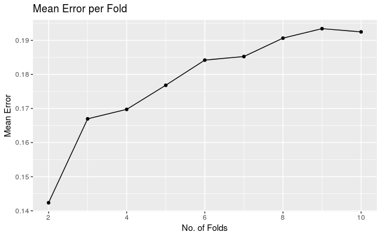

```r
meanError <- meanError[2:10]
errors <- data.frame(Mean = meanError, Folds = 2:10)
ggplot(errors, aes(Folds, Mean)) +
    geom_line() +
    geom_point() +
    labs(title = "Mean Error per Fold") +
    labs(x = "No. of Folds") +
    labs(y = "Mean Error")
```

It’s counter intuitive to have the lowest mean error at the point of 2 folds. I personally suspect my analysis is wrong, but now that I don’t have other data I will go with 5 folds. It’s still yielding a small number of errors while in the same time give the opportunity to have multiple models and this leads to avoiding over-training.